# Les marchés à terme de matières premières

Economie Financière

Simon Jean

simon.jean@agroparistech.fr

AgroParisTech - CIRED - PSAE

## Introduction

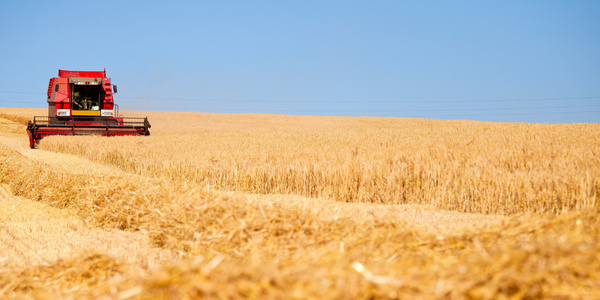

Un agriculteur de la Beauce veut se prémunir des variations de prix entre le moment où il sème et la récolte qu’il aura à vendre l’année prochaine

Un spéculateur à Paris veut tirer profit des variations de prix futures du blé, par exemple en l’achetant aujourd’hui et espérant une augmentation du prix l’année prochaine

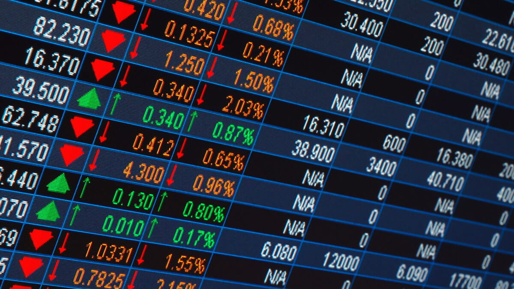

# I. Des promesses sur l’avenir : pourquoi négocie-t-on le futur aujourd’hui ?

## A. La notion de contrat à terme

- Contrats financiers portant sur des actifs physiques (i.e. matières premières, actions, obligations etc)
- à un prix fixé aujourd’hui
- Pour un paiement et une livraison de l’actif dans le futur

On dira qu’un acteur est :

- On est short/court lorsque que l’on a promis de vendre
- On suppose que les prix directs (ou spot) vont baisser: demain, se procurer la marchandise se fera à prix cassé par rapport au contrat, on empoche la différence
- On dit qu’on s’attend à un marché “bear-ish” (baissier) : la courbe des prix a le dos rond, comme un ours
- On est long lorsque l’on a promis d’acheter
- On suppose quee les prix directs (ou spot) vont augmenter: demain, lorsque je vendrai à un prix élevé ce que j’ai acheté à un faible prix dans le contrat, je ferai un gain
- On dit qu’on s’attend à un marché “bull-ish” (haussier) : la courbe des prix est convexe, comme les cornes d’un taureau

## B. Pourquoi faire?

Sans marché à terme :

## B. Pourquoi faire ?

Sans marché à terme :

Avec un marché à terme :

### Débouclage de position

- Le spéculateur s’est engagé à acheter du blé en décembre via un contrat future à 250€/t
- Il veut cependant éviter de devoir gérer la livraison de la marchandise : il est spéculateur, pas logisticien
- Pour ce faire, il peut fin novembre vendre un contrat future pour décembre à 260€/t
- On dit dans ce cas qu’il déboucle sa position :
  - La position d’achat est compensée par une position de vente : il ne détient plus de contrat et s’est libéré de ses obligations
  - Le profit réalisé est : $\Pi = 260-250 = 10$€/t

Pour résumer

[output not shown]

## C. Les acteurs : du producteur à l’arbitragiste

On distingue souvent 3 motifs :

- La couverture (ou hedging) :
  - Pour un céréalier, la baisse des prix du blé implique une baisse de la valeur de son stock (sans flux financier associé nécessairement)
  - Il s’agit ici de limiter les variations de la valeur du stock, en équilibrant une position physique et une position financière
  - Une couverture est parfaite lorsque les variations (flux $F$) de la position physique sont parfaitement compensées par celles de la position financière : $F_{\text{physique},t} - F_{\text{financier, t}}=0$
  - Ces opérations sont souvent faciles à construire sur des marchés liquides et bien régulés
- La spéculation :
  - Pari sur l’évolution des cours
  - Au delà d’une catégorie oisive, il s’agit d’une branche de l’économie financière dont le métier est de traiter l’information disponible pour en tirer profit.
- L’arbitrage :
  - Utilisent les opportunités d’arbitrage, des différences “trop” larges de prix entre marchés physiques et financiers
  - On achète là où le produit est sous-côté pour le revendre là où il est sur-côté
  - Ex : le prix du blé spot est de 200€/t, le coût de stockage jusque décembre est de 5€/t et le prix du future à échéance décembre est de 220€/t
    - J’achète du blé aujourd’hui, vends un future et réalise : $\Pi = 220 - 200 - 5 = 15$ €/t de profit
  - Ce faisant les cours se rapprochent par le jeu de l’offre et de la demande

## D. Des rendements élevés à condition que …

Le premier constat : les marchés permettent de réaliser un large profit avec un minimum de capitaux investis

**L’effet de levier**

Le levier est le ratio entre la valeur contrôlée et le capital investi : plus il est élevé, plus le taux de rendement peut varier, à la hausse comme à la baisse

Pour que le marché à terme soit pérenne, il faut contrôler plusieurs risques :

- Le risque de liquidité :
  - Pour récupérer sa mise, l’actif acheté doit être liquide : le spéculateur doit pouvoir revendre sur le même marché instantanément
  - Cela suppose un grand nombre d’acteurs
  - Et des produits équivalents
- Le risque de contrepartie : le spéculateur s’engage à payer … mais il n’y a pas de garantie réelle qu’il le fasse!
  - Cela suppose de pouvoir éviter les pertes associées aux défauts des parties prenantes

D’autres risques sont inhérents aux comportements sur les marchés :

- Risque de marché : les variations des prix des actifs sous jacents sont hors de contrôle
- Risque de levier : si les leviers multiplient les gains, il peuvent aussi multiplier les pertes
- Risque de couverture (ou risque de base) : les risques liés à la couverture ne sont pas entièrement couverts (on y reviendra)

## E. Différents types de contrats : forward v. futures

Contrats forward

- Négociés entre deux parties et échangés de gré à gré
- Pas standardisés
- Livraison souvent physique
- Liquidité faible à modérée

Contrats futures

- Contrats standardisés et côtés sur un marché
- Complètement standardisés
- Livraison rare
- Liquidité forte

On se concentrera sur les futures dans le cadre de ce cours car ils sont exceptionellement faciles à mettre en place, du fait de leur liquidité, leur standardisation, et les mécanismes de construction du marché

### Un exemple : le contrat Milling Wheat No2 sur Euronext

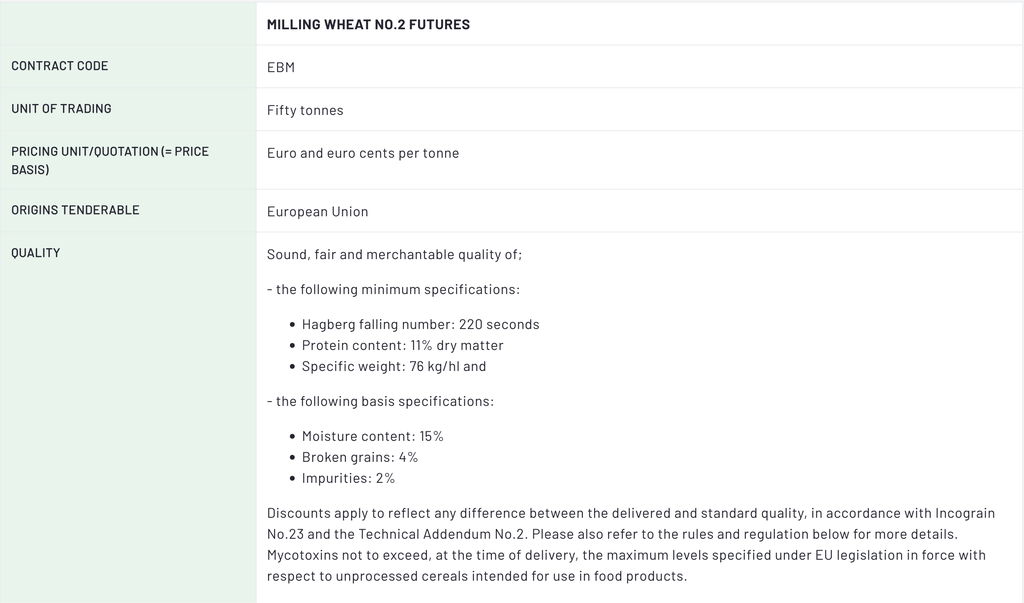

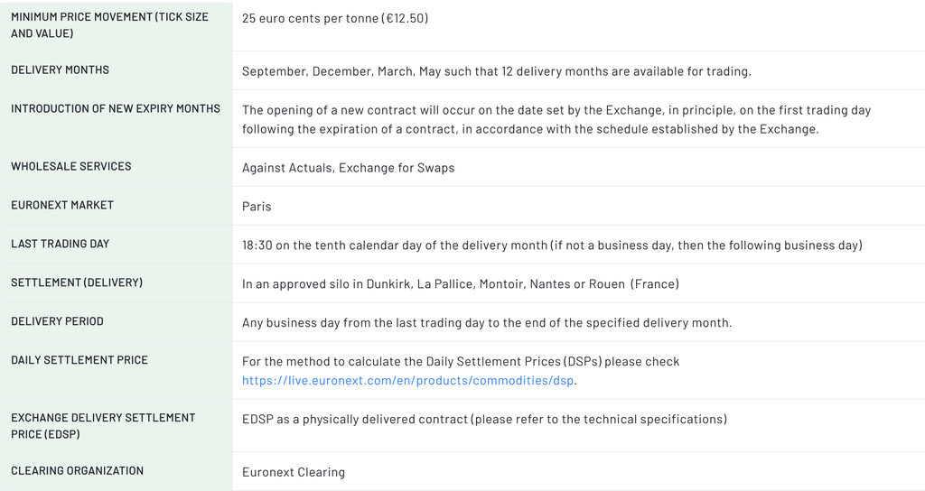

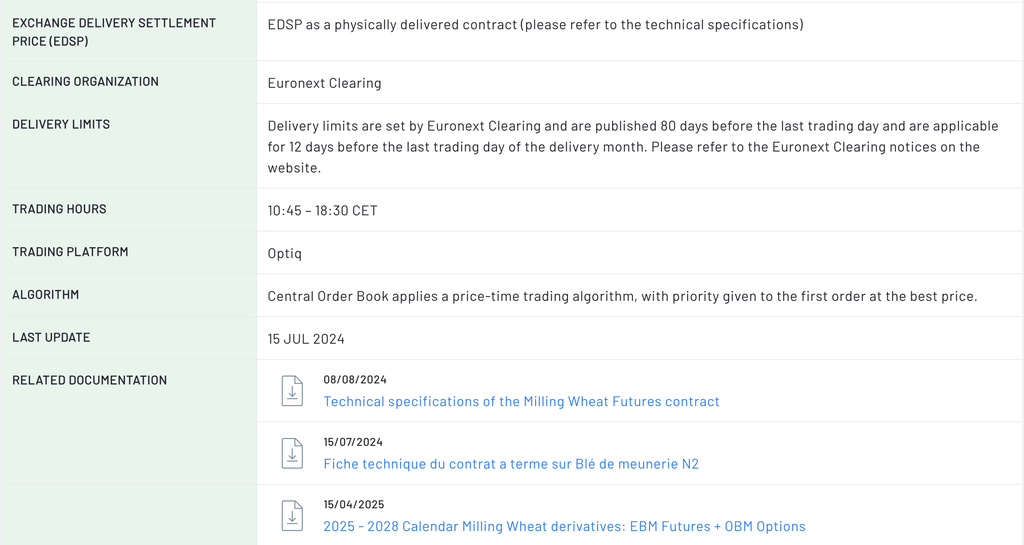

### Les grandes places de marché pour les matières premières

Les places de marché sont des entreprises qui assurent la mise en relation entre acheteurs et vendeurs de produits financiers :

- USA - Chicago Mercantile Exchange Group: céréales, énergie, métaux
  - 1860 : début du trading des futures au Chicago Board of Trade
  - 2006 : fusion avec le Chicago Mercantile Exchange et le New York Mercantile Exchange
  - Leader mondial : plusieurs milliards de contrats par an, toutes catégories confondues.
- Chine :
  - Dalian Commodity Exchange : matières premières agricoles et industrielles.
  - Shanghai Futures Exchange : métaux et énergie
  - Leader régional et mondial en devenir
- Royaume Uni - London Metal Exchange
  - Métaux non ferreux
  - Référence mondiale même si plus modeste en volume
- Europe - Euronext Group
  - Fusion des marchés britanniques, français, allemands
  - Place de référence pour le trading de blé notamment

# II. Mécanique des marchés à terme : un jeu de règles strictes

## A. La négociation du contrat entre parties prenantes

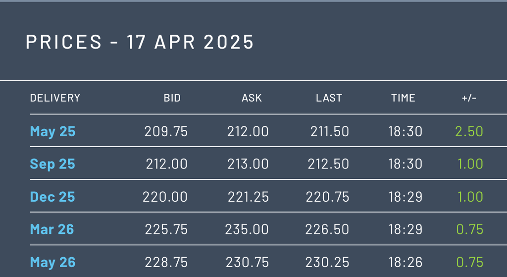

## B. Le rôle de la chambre de compensation

- Organisme privé qui permet de résoudre les problèmes de risque de contrepartie et de défaut
- Principe de novation : la C.C s’interpose entre les acheteurs et les vendeurs :
  - Un contrat de vente est conclu avec l’acheteur
  - Un contrat d’achat est conclu avec le vendeur
  - Ainsi, les contrats sont détenus par la chambre de compensation : si l’une des parties fait défaut, elle assurera la livraison
  - L’assurance de livraison est faite par les dépôts initiaux, un fond de défaut et des capitaux propres
- Principe de compensation : au lieu de solder des dizaines de transactions (en monnaie et en titres) chaque jour entre parties, la chambre de compensation centralise les transactions

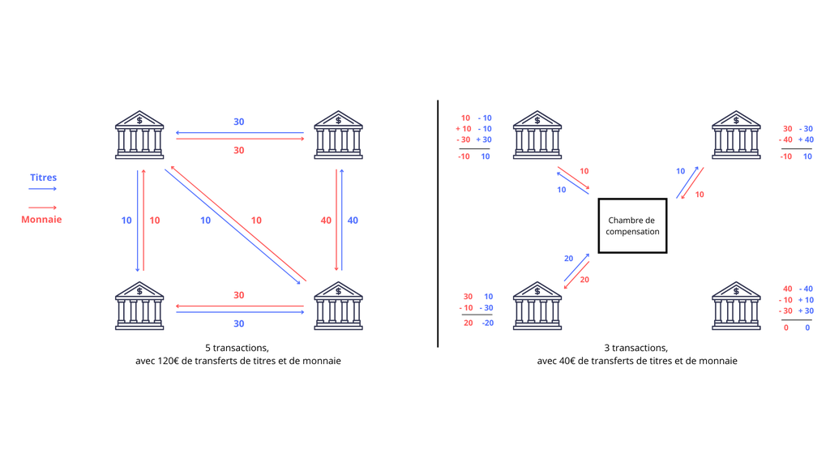

Source : [Banque de France (2024)](https://www.banque-france.fr/fr/publications-et-statistiques/publications/les-chambres-de-compensation)

## C. Le suivi des engagements financiers

- Afin d’éviter le risque de défaut, les chambres de compensation font des ajustements quotidiens des positions
- Ainsi, si la promesse est à terme, le contrat lui, donne lieu à des flux financiers quotidiens
  - “A futures contract is, in effect, closed out and rewritten at a new price each day” John C. Hull
- Au début du contrat, les parties prenantes font un dépôt de marge initiale
- A la fin d’une journée d’échange, la chambre de compensation fait les comptes :
  - Une coopérative a vendu hier (short) un future sur le blé (horizon décembre) à 220€/tonne
  - que lui a acheté (long) un meunier qui se protège d’une hausse des prix
  - Aujourd’hui, le cours est à 210€/tonne :
    - La coopérative avait prévu de vendre à 220€ : elle pourrait racheter aujourd’hui à 210, pour revendre à 220 : elle fait donc un bénéfice de 10€/tonne
    - Le meunier aurait pu acheter à 210€ s’il n’avait pas le contrat : il perd 10€/tonne
- La chambre de compensation effectue des appels de marge pour coller aux cours du marché (mark to market):
  - Afin de s’ajuster à la valeur de sa position, le meunier doit déposer 10€/tonne supplémentaire sur son compte
  - Le compte de la coopérative est crédité de 10€/tonne

Si le meunier ne peut pas faire face à l’appel de marge :

- Sa position est liquidée : il n’a plus de contrat
- Elle est assumée par la chambre de compensation
- Et il est banni du marché, peut être poursuivi en fonction de la taille du défaut

Les contrats futures donnent donc lieu à des flux financiers quotidiens : chaque jour, les appels de marge (coté acheteur)
$$mc_{At} = (f_{t, T} - f_{t-1, T})q$$

- Le flux pour un contrat détenu jusqu’à une date $\tau$ est donc :
  - Pour un acheteur: $mc_A = \sum_{i = 1}^\tau mc_i = (f_{\tau, T} - f_{0, T})q$
  - Pour un vendeur: $mc_V = - mc_A$
- Une position conservée jusqu’à échéance donne ainsi :
  - $mc_A = (f_{T,T} - f_{0,T})q$ et $mc_V = (f_{0,T}-f_{T,T})q$
- Une position débouclée avant échéance à $\tau$ donne lieu à deux flux :
  - Un flux d’acheteur de 0 à T : $mc_A = \sum_{i=1}^T mc_i$
  - Un flux inverse de vendeur de $\tau$ à $T$ : $mc_V = -\sum_{i=\tau}^T mc_i$
  - La position nette est donc : $mc_A + mc_V = \sum_{i=1}^\tau mc_i$
- En pratique, la C.C. ne réalise pas les flux passés le débouclage, mais solde les positions

# III. Ce que disent les prix : entre réalité physique et pari financier

## A. L’évolution conjointe du spot et des futures

### Les coûts de portage : stockage, prime de détention

En équilibre, l’absence d’opportunités d’arbitrage implique que :

- Les coûts liés à la détention physique :
  - L’achat d’une marchandise et son stockage jusqu’à maturité: $S_0+C$
  - Le coût d’opportunité de l’immobilisation de ces capitaux: placés à un taux d’intérêt sans risque $r$, ils rapporteraient $(1+r)^{T}$ ou de façon équivalente, $e^{rT}$
- Soient égaux aux coûts de détention d’un actif financier :
  - Le prix du future : $F_0$
- On a donc en équilibre, en supposant que le coût de stockage est exprimé comme une fraction du spot $u$: $S_0e^{(r+u)T}=F_0$
- Exemple :
  - Une tonne de blé aujourd’hui coûte 200€, dont le coût de stockage est 2€/an (1%) et que le taux d’intérêt est de 3% :
  - Le prix d’un future est donc $F_0 = 200 e^{0.04}=208.16$
  - On est en contango
- Supposons maintenant que l’actif n’a pas qu’une valeur en tant qu’actif financier, mais aussi en tant que bien de consommation, d’usage
- Il peut y avoir une prime à la détention : anticipations de stocks mondiaux faibles, demande importante, nécessité dans un processus de production à temps $t$
- Dans ce cas, on dit qu’il y a un convenience yield (i.e. un rendement de convenance)
  - D’un côté, le coût de détention dans le temps de l’actif est mitigé par le rendement de convenance : $S_0e^{(r+u-y)T}$
  - De l’autre le prix de l’actif : $F_0$
- Le coût de portage est la somme des coûts de stockage et de rendements de convenance
- Si le rendement de convenance est suffisament large, on peut être en backwardation

## B. Des marchés de spéculation plus que de couverture ?

### A la recherche du hedge parfait …

Lorsqu’un fermier veut se prémunir des variations du prix, il s’engage dans un hedge :

- Il équilibre les variations du marché physique
- Avec un engagement financier

Formellement, le revenu issu d’une opération de hedge sur deux périodes est:

- Si $T$ est l’échéance du hedge, alors le hedge peut être parfait : on détient le contrat jusqu’à maturité, de sorte que $s_T=f_{T,T}$
  - Le revenu est connu à l’avance
  - Les variations du prix spot sont complètement compensées par les flux engendrés par le future:
    - La vente physique engendre un bénéfice de $s_T$€/t
    - Je solde ma position sur le marché, et achète un contrat à $f_{T,T}$ : j’engrange $f_{t,0}-f_{T,T}$€/t
    - Donc in fine, je récupère $f_{t,0}$€/t
- En effet, lorsque je maintiens ma position, la base tend vers 0

### Sans échapper à la spéculation

- Peu de hedges sont maintenus jusqu’à échéance : on peut vouloir vendre plus tôt que la livraison initialement prévue dans le cadre du contrat
- Dès lors, si $\tau$ est maintenant la date de débouclage, il est probable que : $s_{\tau} \neq f_{\tau,T}$
- On peut réécrire le revenu comme :

$$\begin{align*}
R &= f_{t0,T} + b_\tau\\
R & = s_{t0} + b_\tau - b_{t0}
\end{align*}$$

- Dans ce cas, le hedge est parfait si la base n’évolue pas dans le temps
- Ceci est peu probable : quand on hedge, on spécule en fait sur l’évolution de cette base, pour en tirer profit

# Conclusion

1. **Le marché à terme permet de négocier aujourd’hui un prix futur**
   - Des engagements fermes pour sécuriser un prix dans un contexte incertain.
2. **Trois usages principaux des contrats à terme**
   - **Couverture**, **spéculation**, **arbitrage** : chaque acteur a sa logique.
3. **Un marché sécurisé par la chambre de compensation**
   - Elle limite les risques de défaut grâce à la **novation** et aux **appels de marge**.
4. **Un effet de levier puissant mais risqué**
   - Les **profits peuvent être élevés**, mais les **pertes aussi** : rigueur et liquidité indispensables.
5. **Les prix à terme reflètent plus que le marché physique**
   - **Coûts de stockage, taux d’intérêt, rendement de convenance** : un prix qui intègre aussi la logique financière.
   - **Le hedge “parfait” est rare :** il y a toujours une part de spéculation.